# Infinite Impulse Response / Feedback Filters

## Single Delay Feedback Filters

```python
import numpy as np
import matplotlib.pyplot as plt
from scipy import signal
import IPython.display as ipd
```

We can modify our difference equations to include *feedback* terms; that is, we can add terms that come from past *outputs* instead of past inputs. In particular, the general form of a single delay feedback filter is

### Ex) $ y[n] = x[n] + \alpha y[n-T] $

this gives rise to an interesting effect that we didn't have with finite impulse response convolutional filters before; that is, we can get instabilities where certain frequencies grow without bound. Below is some code to evaluate this and show this effect when $\alpha = 1$ and $T = 10$:

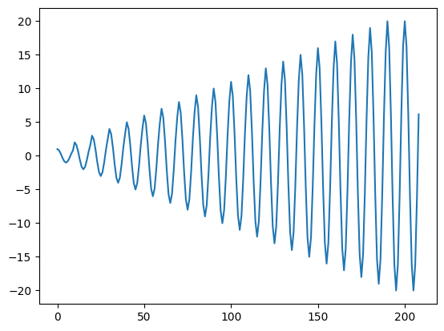

```python
def apply_one_lag_filter(x, T, alpha):
    y = np.zeros(len(x)+T-1)
    for n in range(len(y)):
        if n < len(x):
            y[n] += x[n]
        if n >= T:
            y[n] += alpha*y[n-T]
    return y

np.random.seed(0)
T = 10
k = 1
w = 2*np.pi*k/T
ns = np.arange(200)
x = np.cos(w*ns)
alpha = 1
y = apply_one_lag_filter(x, T, alpha)
plt.plot(y)
```

to see why this happens analytically, we can use the z-transform on the terms that depend on y *and* the terms that depend on $x$. Starting again with the equation

$ y[n] = x[n] + \alpha y[n-T] $

Assume that input $x[n] = e^{j \omega n}$, then $y[n] = A e^{j \omega n + \phi}$

$ y[n] - \alpha y[n-T] = x[n] $

$y[n-T] = A e^{j \omega (n-T) + \phi} = A e^{j \omega n + \phi} e^{-j \omega T} = y[n] e^{-j \omega T}$

Therefore, this equation can be written as

#### $ y[n](1 - \alpha e^{-j \omega T}) = x[n] $

which can be re-arranged into

### $ y[n] = x[n]\frac{1}{(1 - \alpha e^{-j \omega T})} = x[n] \frac{1}{(1 - \alpha z^{-T})} $

### NOTE: $ \frac{1}{(1 - e^{-j \omega T})} = \frac{e^{j \omega T /2}}{i} \frac{1}{2 \sin(\omega T /2 )} $

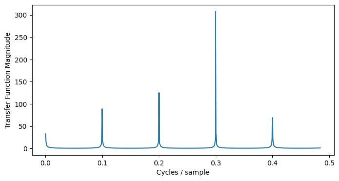

```python
plt.figure(figsize=(8, 4))
T = 10
w = np.linspace(0, np.pi-0.1, 1000)
f = w / (2*np.pi)
plt.plot(f, np.abs(1/(2*np.sin(w*T/2))))
plt.xlabel("Cycles / sample")
plt.ylabel("Transfer Function Magnitude")
```

Let's solve for values of $\omega$ that will make the denominator 0 when $\alpha = 1$

$wT = 2\pi k$

Therefore, if $w = 2 \pi k /T $ and $\alpha = 1$, then the equation blows up.

Even if we send random noise through such a filter, we will get a signal that grows without bound, because it will contain some of these unstable frequencies. This is precisely what happens when a microphone "feeds back" into a speaker

[interactive chart not shown]

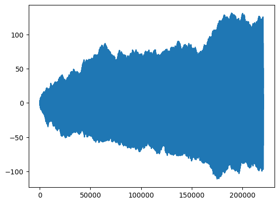

```python
sr = 44100
T = 100
x = np.random.randn(5*sr)
alpha = 1
y = apply_one_lag_filter(x, T, alpha)
plt.plot(y)
ipd.Audio(y, rate=sr)
```

A "pole" is the term for such a root that leads to a zero denominator of the transfer function of $x$. If we make $0 < \alpha < 1$, then the poles move insie of the circle in the complex plane, but they still pull up the points on the unit circle near them. For example, if $\alpha = 0.9$, then plugging in $z = e^{i \omega T}$ yields a magnitude of $\frac{1}{1 - 0.9} = 10$. If $\alpha = 0.99$, then it will yield a magnitude of $\frac{1}{1 - 0.99} = 100$.

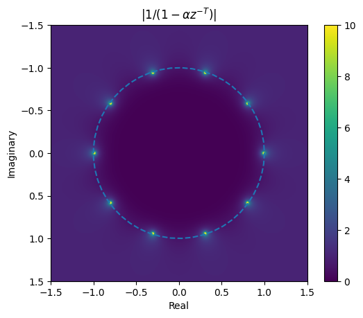

```python
T = 10
pix = np.linspace(-1.5, 1.5, 512)
re, im = np.meshgrid(pix, pix)
z = re + 1j*im
alpha = 0.9
mags = np.abs(1/(1-alpha*z**(-T)))
plt.imshow(mags, extent=(pix[0], pix[-1], pix[-1], pix[0]), vmin=0, vmax=10)
plt.colorbar()
t = np.linspace(0, 2*np.pi)
plt.plot(np.cos(t), np.sin(t), linestyle='--')
plt.title("$| 1/(1 - \\alpha z^{-T})|$")
plt.xlabel("Real")
plt.ylabel("Imaginary")
```

Note also the connection to Karplus strong, which we saw in homework 2. If we fill $x$ with just a little bit of random noise at the beginning and we pick some $0 < \alpha < 1$, then we get a plucked string sound. The closer $\alpha$ is to 1, the longer the sound rings out

[interactive chart not shown]

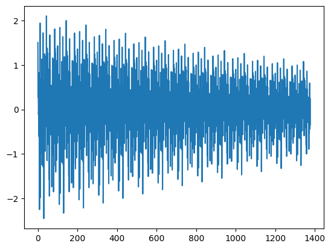

```python
sr = 44100
T = 100
alpha = 0.95
x = np.zeros(sr)
x[0:T] = np.random.randn(T)
y = apply_one_lag_filter(x, T, alpha)
plt.plot(y[0:sr//32])
ipd.Audio(y, rate=sr)
```

Finally, it's worth explaining where the term "infinite impulse response" comes from. If $|\alpha| < 1$, then we can recognize the expression

### $ y[n] = x[n]\frac{1}{(1 - \alpha e^{-j \omega T})} $

as the result of an infinite geometric series:

### $ y[n] = x[n] \left( 1 + \alpha e^{-j \omega T} + \alpha^2 e^{-2j \omega T} + \alpha^3 e^{-3j \omega T} + ... \right) $

### $y[n] = x[n] + \alpha x[n -T] + \alpha^2 x[n - 2T] + \alpha^2 x[n - 3T] + ... $

Written as an impulse response, we're saying

### $h[0] = 1, h[T] = \alpha, h[2T] = \alpha^2, h[3] = \alpha^3, ...$

Below is an example showing numerically what happens when we send an impulse through a filter with $T = 10$ and $\alpha = 0.9$

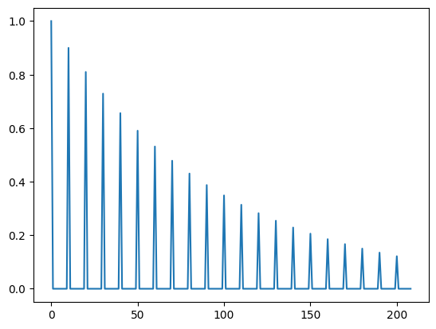

```python
def apply_one_lag_filter(x, T, alpha):
    y = np.zeros(len(x)+T-1)
    for n in range(len(y)):
        if n < len(x):
            y[n] += x[n]
        if n >= T:
            y[n] += alpha*y[n-T]
    return y

x = np.zeros(200)
x[0] = 1
T = 10
alpha = 0.9
plt.plot(apply_one_lag_filter(x, T, alpha))
```

## General Form of Feedback Filters

$a[0]y[n] = (b[0]x[n] + b[1]x[n-1] + b[2]x[n-2] + ...) - ( a[1]y[n-1] + a[2]y[n-2] + a[3]y[n-3] + ... )$

$a[0]y[n] + a[1]y[n-1] + a[2]y[n-2] + a[3]y[n-3] + ... = b[0]x[n] + b[1]x[n-1] + b[2]x[n-2] + ... $

$a[0]y[n] + a[1]y[n]z^{-1} + a[2]y[n]z^{-2} + ... = b[0]x[n] + b[1]x[n]z^{-1} + b[2]x[n]z^{-2} + ...$

$y[n](a[0] + a[1]z^{-1} + a[2]z^{-2} + ...) = x[n](b[0] + b[1]z^{-1} + b[2]z^{-2} + ...)$

### $y[n] = x[n] \frac{(b[0] + b[1]z^{-1} + b[2]z^{-2} + ...)}{(a[0] + a[1]z^{-1} + a[2]z^{-2} + ...)}$

### Ex) $y[n] = x[n] - ( -\alpha y[n-T])$

### $\frac{1}{(1 - \alpha z^{-T})}$

### Ex) $ y[n] = x[n] - (-y[n-2] -y[n-3] + y[n-5]) $

### $y[n] = x[n] \frac{1}{1 - z^{-2} - z^{-3} + z^{-5}}$

### $y[n] = x[n] \frac{1}{(1 - z^{-2})(1 - z^{-3})}$

### $y[n] = x[n] \frac{(b[0] + b[1]z^{-1} + b[2]z^{-2} + ...)}{(a[0] + a[1]z^{-1} + a[2]z^{-2} + ...)}$

```python
def eval_filter(b, a, x):
    assert(a[0] != 0)
    y = np.zeros(len(x))
    for n in range(len(y)):
        ## Loop through feed-forward (convolutional) lag terms in x
        for i in range(len(b)):
            if i <= n:
                y[n] += b[i]*x[n-i]
        ## Loop through the feedback terms (lags of y)
        for i in range(1, len(a)):
            if i <= n:
                y[n] -= a[i]*y[n-i]
        y[n] /= a[0]
    return y
```

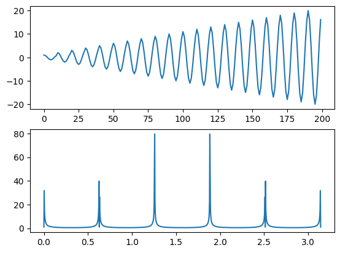

```python
def get_transfer_function(b, a, z, eps=1e-2):
    num = complex(0, 0)
    for i in range(len(b)):
        num += b[i]*(z**(-i))
    denom = complex(0, 0)
    for i in range(len(a)):
        denom += a[i]*(z**(-i))
    if np.abs(denom) < eps:
        denom = 1
    return num/denom

def get_transfer_function_semicircle(b, a, n=1000, eps=1e-2):
    ws = np.linspace(0, np.pi, n)
    return ws, [get_transfer_function(b, a, np.exp(1j*w), eps) for w in ws]


T = 10
alpha = 1
a = np.zeros(T+1)
a[0] = 1
a[T] = -alpha
b = [1]
k = 1
w = 2*np.pi*k/T
ns = np.arange(200)
x = np.cos(w*ns)
y = eval_filter(b, a, x)

plt.subplot(211)
plt.plot(y)
plt.subplot(212)
zs, H = get_transfer_function_semicircle(b, a)
plt.plot(zs, np.abs(H))
```

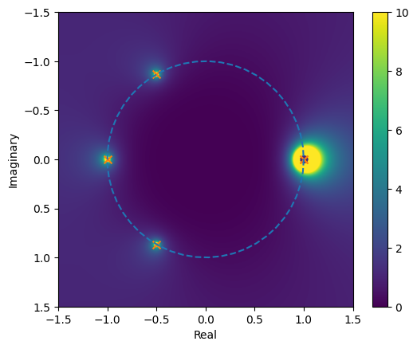

```python
def plot_complex_plane(b, a, rg=1.5, res=512, vmin=0, vmax=10):
    pix = np.linspace(-rg, rg, res)
    re, im = np.meshgrid(pix, pix)
    z = re + 1j*im
    mags = np.zeros(z.shape)
    for i in range(len(z)):
        for j in range(len(z[i])):
            mags[i, j] = np.abs(get_transfer_function(b, a, z[i, j]))
    plt.imshow(mags, extent=(pix[0], pix[-1], pix[-1], pix[0]), vmin=vmin, vmax=vmax)
    plt.colorbar()
    t = np.linspace(0, 2*np.pi)
    plt.plot(np.cos(t), np.sin(t), linestyle='--')
    plt.xlabel("Real")
    plt.ylabel("Imaginary")


b = [1]
alpha = 0.1
a = [1, 0, -1, -1, 0, 1]


plot_complex_plane(b, a)

zeros, poles, _ = signal.tf2zpk(b, a)
for z in zeros:
    plt.scatter(np.real(z), np.imag(z), c='C1', s=10)
for p in poles:
    plt.scatter(np.real(p), np.imag(p), marker='x', c='C1', s=50)
```